# IPL Exploratory Data Analysis

## By: Arsh Dinesh Vijayvargiya

## Importing Essential Libraries

```python
import pandas as pd
import numpy as np
import seaborn as sns
import matplotlib.pyplot as plt
```

## Reading Dataset

```python
deli_df = pd.read_csv(r'deliveries.csv')
mat_df = pd.read_csv(r'matches.csv')
runs_df = pd.read_csv(r'most_runs_average_strikerate.csv')
teams_df = pd.read_csv(r'teams.csv')
loc_df = pd.read_csv(r'teamwise_home_and_away.csv')
players_df = pd.read_excel(r'Players.xlsx')
```

#### Working with each datasets

```python
players_df.info()
```

```
<class 'pandas.core.frame.DataFrame'>
RangeIndex: 566 entries, 0 to 565
Data columns (total 5 columns):
 #   Column         Non-Null Count  Dtype
---  ------         --------------  -----
 0   Player_Name    566 non-null    object
 1   DOB            471 non-null    datetime64[ns]
 2   Batting_Hand   563 non-null    object
 3   Bowling_Skill  502 non-null    object
 4   Country        471 non-null    object
dtypes: datetime64[ns](1), object(4)
memory usage: 22.2+ KB
```

Opinion on Dataframe:

1. Country will be used to see the participation from the world
2. Batting Hand & Bowling_Skill would be good for plotting

```python
runs_df.info()
```

```
<class 'pandas.core.frame.DataFrame'>
RangeIndex: 516 entries, 0 to 515
Data columns (total 6 columns):
 #   Column         Non-Null Count  Dtype
---  ------         --------------  -----
 0   batsman        516 non-null    object
 1   total_runs     516 non-null    int64
 2   out            516 non-null    int64
 3   numberofballs  516 non-null    int64
 4   average        482 non-null    float64
 5   strikerate     516 non-null    float64
dtypes: float64(2), int64(3), object(1)
memory usage: 24.3+ KB
```

Opinion on Dataframe: This dataframe would give us great insight in analysing Batsman

```python
teams_df.info()
```

```
<class 'pandas.core.frame.DataFrame'>
RangeIndex: 15 entries, 0 to 14
Data columns (total 1 columns):
 #   Column  Non-Null Count  Dtype
---  ------  --------------  -----
 0   team1   15 non-null     object
dtypes: object(1)
memory usage: 248.0+ bytes
```

Opinion on Dataframe:

1. No Use Whatsoever

```python
deli_df.info()
```

```
<class 'pandas.core.frame.DataFrame'>
RangeIndex: 179078 entries, 0 to 179077
Data columns (total 21 columns):
 #   Column            Non-Null Count   Dtype
---  ------            --------------   -----
 0   match_id          179078 non-null  int64
 1   inning            179078 non-null  int64
 2   batting_team      179078 non-null  object
 3   bowling_team      179078 non-null  object
 4   over              179078 non-null  int64
 5   ball              179078 non-null  int64
 6   batsman           179078 non-null  object
 7   non_striker       179078 non-null  object
 8   bowler            179078 non-null  object
 9   is_super_over     179078 non-null  int64
 10  wide_runs         179078 non-null  int64
 11  bye_runs          179078 non-null  int64
 12  legbye_runs       179078 non-null  int64
 13  noball_runs       179078 non-null  int64
 14  penalty_runs      179078 non-null  int64
 15  batsman_runs      179078 non-null  int64
 16  extra_runs        179078 non-null  int64
 17  total_runs        179078 non-null  int64
 18  player_dismissed  8834 non-null    object
 19  dismissal_kind    8834 non-null    object
 20  fielder           6448 non-null    object
dtypes: int64(13), object(8)
memory usage: 28.7+ MB
```

Opinion on Dataframe:

1. This is a great dataframe for digging in insights, loads of insight could be derived from this dataset by grouping various data

```python
mat_df.info()
```

```
<class 'pandas.core.frame.DataFrame'>
RangeIndex: 756 entries, 0 to 755
Data columns (total 18 columns):
 #   Column           Non-Null Count  Dtype
---  ------           --------------  -----
 0   id               756 non-null    int64
 1   Season           756 non-null    object
 2   city             749 non-null    object
 3   date             756 non-null    object
 4   team1            756 non-null    object
 5   team2            756 non-null    object
 6   toss_winner      756 non-null    object
 7   toss_decision    756 non-null    object
 8   result           756 non-null    object
 9   dl_applied       756 non-null    int64
 10  winner           752 non-null    object
 11  win_by_runs      756 non-null    int64
 12  win_by_wickets   756 non-null    int64
 13  player_of_match  752 non-null    object
 14  venue            756 non-null    object
 15  umpire1          754 non-null    object
 16  umpire2          754 non-null    object
 17  umpire3          119 non-null    object
dtypes: int64(4), object(14)
memory usage: 106.4+ KB
```

Opinion on Dataframe: Good dataset for coorelation and insights

```python
loc_df.info()
```

```
<class 'pandas.core.frame.DataFrame'>
RangeIndex: 14 entries, 0 to 13
Data columns (total 7 columns):
 #   Column               Non-Null Count  Dtype
---  ------               --------------  -----
 0   team                 14 non-null     object
 1   home_wins            14 non-null     int64
 2   away_wins            14 non-null     int64
 3   home_matches         14 non-null     int64
 4   away_matches         14 non-null     int64
 5   home_win_percentage  14 non-null     float64
 6   away_win_percentage  14 non-null     float64
dtypes: float64(2), int64(4), object(1)
memory usage: 912.0+ bytes
```

Opinion on Dataframe: This dataset would be great in analysing effect of location on the mind of players

```python
# Data Correction

deli_df.batting_team[deli_df.batting_team == 'Rising Pune Supergiants'] = 'Rising Pune Supergiant'
deli_df.bowling_team[deli_df.bowling_team == 'Rising Pune Supergiants'] = 'Rising Pune Supergiant'
```

## General Analysis

```python
# Colors
crimson = '#DC143C'
green = '#69995D'
black = '#223127'
navy_blue = '#150578'
golden = '#E6AF2E'
sea_blue = "#1B9AAA"
```

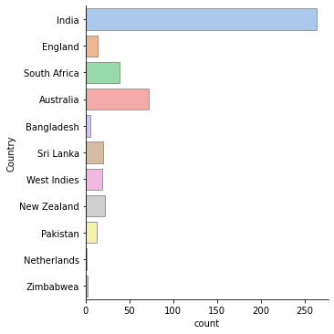

```python
# Plt_1: Players Participation from the globe

plt.figure(figsize=(15,8))
sns.catplot(y="Country", kind="count",
            palette="pastel", edgecolor=".6",
            data=players_df)
plt.show()
```

###### Insight:

1. Most players participated in IPL were from India.
2. Australia has maximum participation as a foreign country.

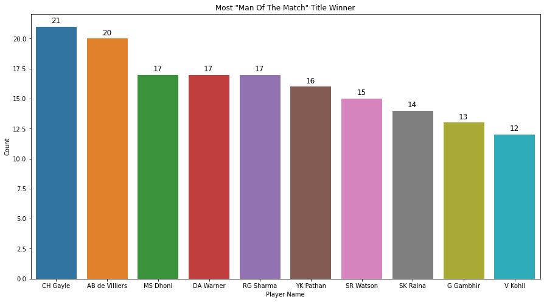

```python
# Top 10 most Man of the match

man_of_match = mat_df.groupby(['player_of_match']).count()['id']
man_of_match = man_of_match.sort_values(ascending = False).head(10)
player_name = man_of_match.index
# plotting
fig,ax = plt.subplots(figsize=(15,8))
sns.barplot(player_name,man_of_match)
for index,data in enumerate(man_of_match):
    plt.text(x=index-0.1 , y =data+0.3 , s=f"{data}" , fontdict=dict(fontsize=12))
plt.xlabel('Player Name')
plt.ylabel('Count')
plt.title('Most "Man Of The Match" Title Winner')
plt.show()
```

##### Insight:

Chris Gayle and AB de Villers has taken the throne of "MAN OF THE MATCH" most of the times, with Chris Gayle being in lead of 1.

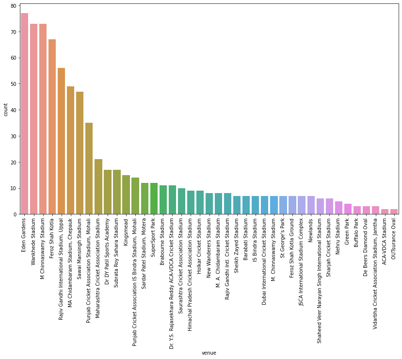

```python
#Number of matches per venue

plt.figure(figsize=(14,8))
sns.countplot(x='venue', data=mat_df, order=pd.value_counts(mat_df['venue']).index)
plt.xticks(rotation='vertical')
plt.show()
```

##### Insight:

Eden Garden in Kolkata has been the top site for for oraganising an match.

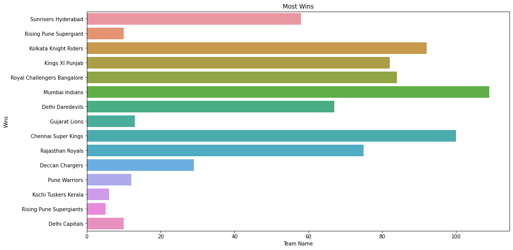

```python
# Most Winning Team

fig,ax = plt.subplots(figsize=(15,8))
sns.countplot(y='winner',data = mat_df)
plt.xlabel('Team Name')
plt.ylabel('Wins')
plt.title('Most Wins')

plt.show()
```

##### Insight: Mumbai Indians has scored the most overall wins in IPL.

```python
# Most Time Champions and Most Times Final Qualified

mat_df['Season'] = mat_df.Season.apply(lambda x: int(x.split("-")[1]))
```

```python
Season_winner = {x:0 for x in teams_df['team1']}
teams_finalise = {x:0 for x in teams_df['team1']}
for sea in mat_df.Season.unique():
    Season_winner[mat_df[mat_df.Season == sea]['winner'].iloc[-1]] += 1
    teams_finalise[mat_df[mat_df.Season == sea]['team1'].iloc[-1]] += 1
    teams_finalise[mat_df[mat_df.Season == sea]['team2'].iloc[-1]] += 1
```

```python
Season_winner
```

```
{'Pune Warriors': 0,
 'Kolkata Knight Riders': 2,
 'Rajasthan Royals': 1,
 'Kochi Tuskers Kerala': 0,
 'Gujarat Lions': 0,
 'Chennai Super Kings': 3,
 'Rising Pune Supergiants': 0,
 'Delhi Daredevils': 0,
 'Deccan Chargers': 1,
 'Delhi Capitals': 0,
 'Mumbai Indians': 4,
 'Sunrisers Hyderabad': 1,
 'Rising Pune Supergiant': 0,
 'Royal Challengers Bangalore': 0,
 'Kings XI Punjab': 0}
```

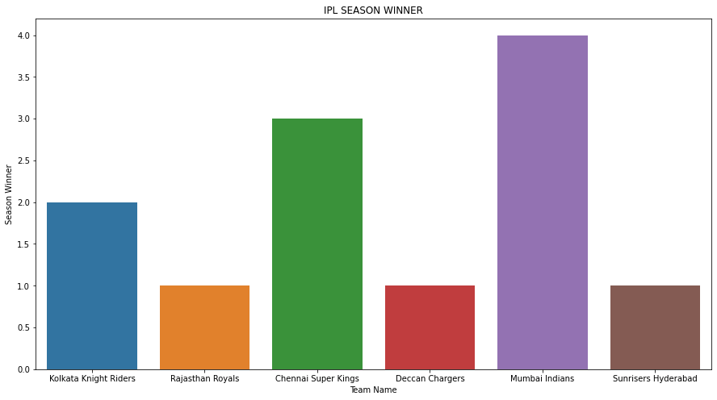

```python
Winning_Team = {x:y for x,y in Season_winner.items() if y!=0}
fig,ax = plt.subplots(figsize=(15,8))
sns.barplot(x = list(Winning_Team.keys()), y =list(Winning_Team.values()))
plt.xlabel('Team Name')
plt.ylabel('Season Winner')
plt.title('IPL SEASON WINNER')
```

```python
teams_finalise
```

```
{'Pune Warriors': 0,
 'Kolkata Knight Riders': 2,
 'Rajasthan Royals': 1,
 'Kochi Tuskers Kerala': 0,
 'Gujarat Lions': 0,
 'Chennai Super Kings': 8,
 'Rising Pune Supergiants': 0,
 'Delhi Daredevils': 0,
 'Deccan Chargers': 1,
 'Delhi Capitals': 0,
 'Mumbai Indians': 5,
 'Sunrisers Hyderabad': 2,
 'Rising Pune Supergiant': 1,
 'Royal Challengers Bangalore': 3,
 'Kings XI Punjab': 1}
```

```python
Finalists = {x:y for x,y in teams_finalise.items() if y!=0}
Season_winner  = {x:y for x,y in Season_winner.items() if x in Finalists.keys()}
```

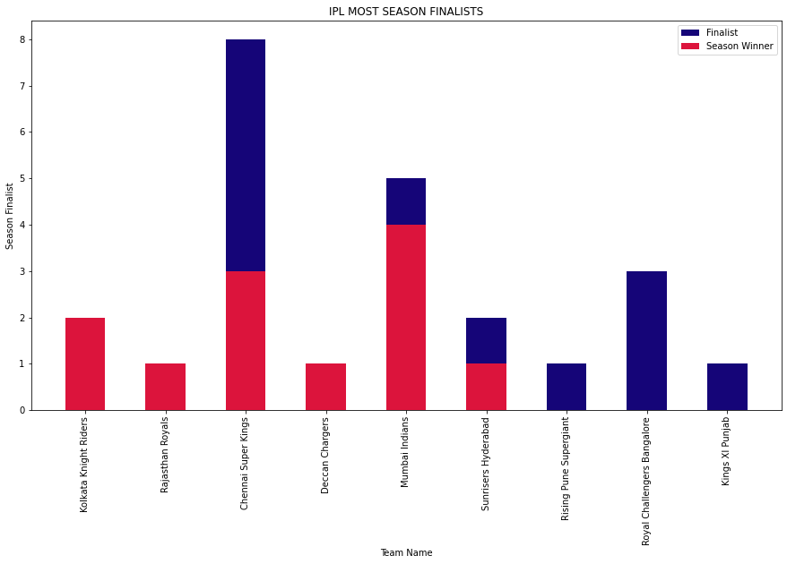

```python
fig,ax = plt.subplots(figsize=(15,8))
plt.bar(list(Finalists.keys()),list(Finalists.values()),label="Finalist",width=.5, color = navy_blue)
plt.bar(list(Finalists.keys()),list(Season_winner.values()),label="Season Winner", color=crimson,width=0.5)
plt.xlabel('Team Name')
plt.ylabel('Season Finalist')
plt.legend()
plt.title('IPL MOST SEASON FINALISTS')
plt.xticks(rotation='vertical')
plt.show()
```

##### Insight: KKR, RR and DC has won every finals they been to. CSK has played the most IPL finals.

```python
team_runs = deli_df.groupby('batting_team')['total_runs'].count()
runs_dict = dict(team_runs)
```

```python
loc_df['total_matches'] = loc_df['home_matches'] + loc_df['away_matches']

loc_df['total_wins'] = loc_df['home_wins'] + loc_df['away_wins']
loc_df['Win_percentage'] = (loc_df['total_wins']/loc_df['total_matches'])*100
```

```python
total_mat = []
for team in runs_dict:
    total_mat.append(loc_df.total_matches[loc_df.team ==team].reset_index(drop = True).iloc[0])
```

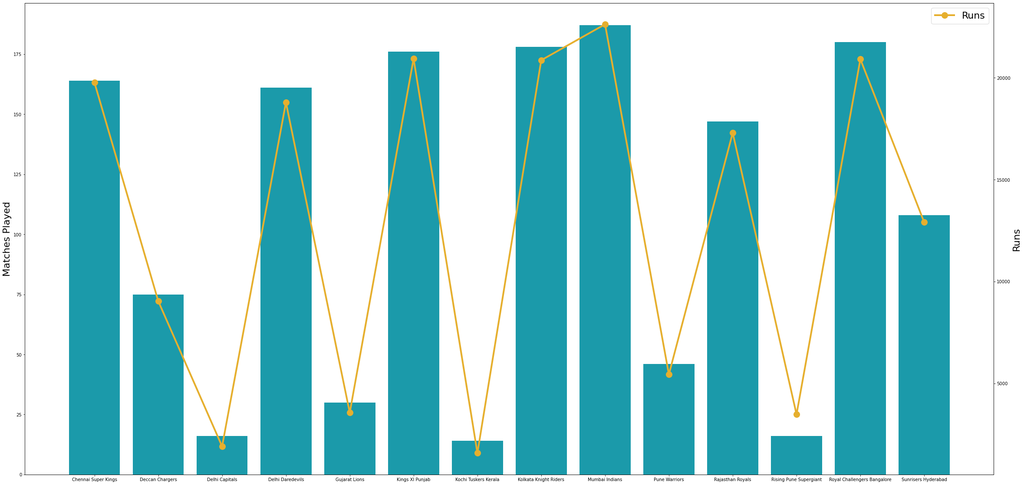

```python
# Total_runs by each team

fig, ax1 = plt.subplots(figsize=(40,20))
ax2 = ax1.twinx()
ax1.bar(team_runs.index, total_mat, label="match_played", color= sea_blue)
ax1.set_ylabel('Matches Played', fontsize = 22)
ax2.set_ylabel('Runs', fontsize = 22)
ax2.plot(team_runs.index,team_runs , label="Runs", color=golden, marker = 'o', linewidth = 4, markersize = 14)
ax2.legend(fontsize= 22)
```

##### Insight : As expected Matches played is highly corelated to total runs scored by a team. Mumbai Indians has played maximum matches and has maximum runs scored in IPL

## Location Analysis

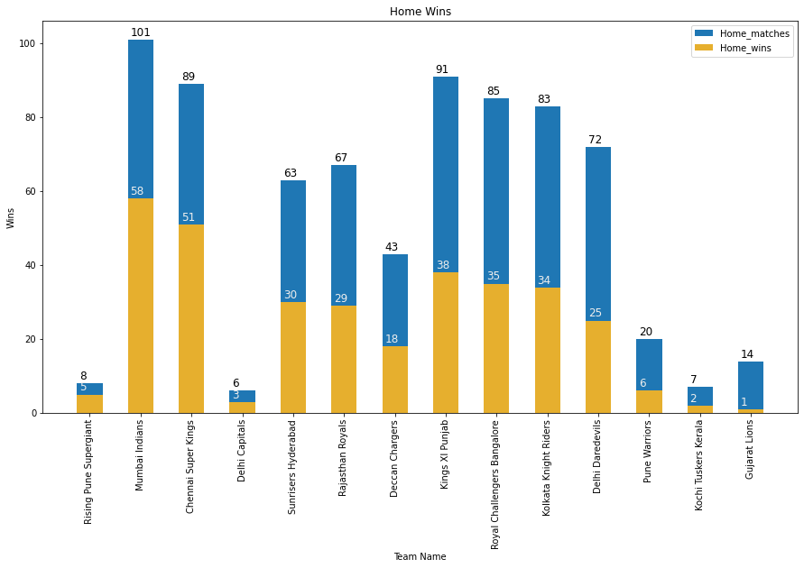

```python
# Home Wins

fig,ax = plt.subplots(figsize=(15,8))
plt.bar(loc_df['team'],loc_df['home_matches'],label="Home_matches",width=.5)
plt.bar(loc_df['team'],loc_df['home_wins'],label="Home_wins", color = golden,width=0.5)
for index,data in enumerate(loc_df['home_wins']):
    plt.text(x=index-0.2 , y =data+ 1 , s="{}".format(data) , fontdict=dict(fontsize=12) , color ='#EEEEEE' )
for index,data in enumerate(loc_df['home_matches']):
    plt.text(x=index-0.2 , y =data+ 1 , s="{}".format(data) , fontdict=dict(fontsize=12))
plt.xlabel('Team Name')
plt.ylabel('Wins')
plt.title('Home Wins')
plt.xticks(rotation='vertical')
plt.legend()

plt.show()
```

##### Insight:

1. Mumbai Indians has played more matches in home than any team and Hence has won more times.

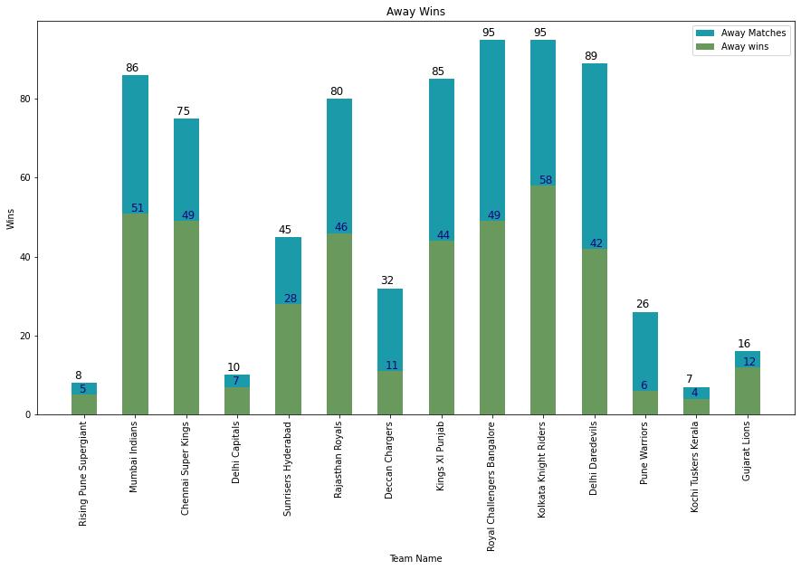

```python
fig,ax = plt.subplots(figsize=(15,8))
plt.bar(loc_df['team'],loc_df['away_matches'],label="Away Matches",width=.5, color = '#1B9AAA')
plt.bar(loc_df['team'],loc_df['away_wins'],label="Away wins", color= green ,width=0.5)
for index,data in enumerate(loc_df['away_wins']):
    plt.text(x=index-0.1 , y =data+ 0.5 , s="{}".format(data) , fontdict=dict(fontsize=12) , color = navy_blue)
for index,data in enumerate(loc_df['away_matches']):
    plt.text(x=index-0.2 , y =data+ 1 , s="{}".format(data) , fontdict=dict(fontsize=12))
plt.xlabel('Team Name')
plt.ylabel('Wins')
plt.title('Away Wins')
plt.xticks(rotation='vertical')
plt.legend()

plt.show()
```

##### Insight:

1. KKR and RCB has played more away matches than any team.
2. KKR has edge over RCB as they have won more away matches than them.

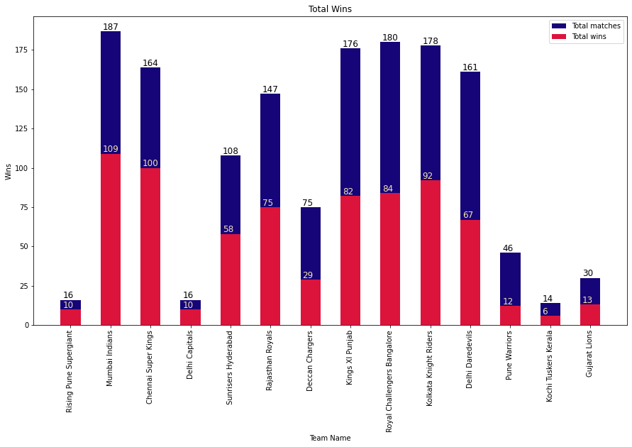

```python
fig,ax = plt.subplots(figsize=(15,8))
plt.bar(loc_df['team'],loc_df['total_matches'],label="Total matches",width=.5, color = navy_blue)
plt.bar(loc_df['team'],loc_df['total_wins'],label="Total wins", color=crimson,width=0.5)
for index,data in enumerate(loc_df['total_wins']):
    plt.text(x=index-0.2 , y =data+ 1 , s="{}".format(data) , fontdict=dict(fontsize=12) , color = "#F4E3B2")
for index,data in enumerate(loc_df['total_matches']):
    plt.text(x=index-0.2 , y =data+ 1 , s="{}".format(data) , fontdict=dict(fontsize=12))
plt.xlabel('Team Name')
plt.ylabel('Wins')
plt.title('Total Wins')
plt.xticks(rotation='vertical')
plt.legend()

plt.show()
```

##### Insight:

1. Mumbai Indians has played and won more matches than any team
2. This shows the correlation between winning and matches played, the more you win , more matches you get to play.

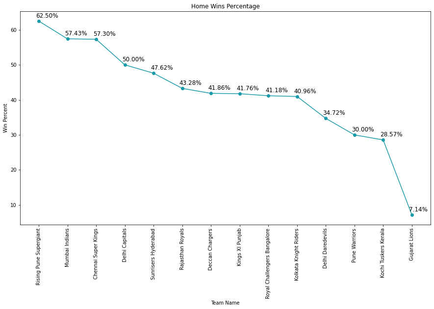

```python
fig,ax = plt.subplots(figsize=(15,8))
plt.plot(loc_df['team'],loc_df['home_win_percentage'], marker = 'o', color = sea_blue)
for index,data in enumerate(loc_df['home_win_percentage']):
    plt.text(x=index-0.1 , y =data+ 1 , s="{:.2f}%".format(data) , fontdict=dict(fontsize=12))
plt.xlabel('Team Name')
plt.ylabel('Win Percent')
plt.title('Home Wins Percentage')
plt.xticks(rotation='vertical')
plt.show()
```

##### Insight:

Rising Pune Supergiants has a very high probablity of winning a match if it is hosted in their home ground.

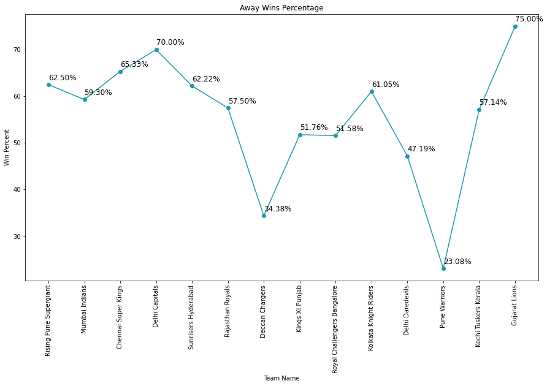

```python
fig,ax = plt.subplots(figsize=(15,8))
plt.plot(loc_df['team'],loc_df['away_win_percentage'], marker = 'o', color = sea_blue)
for index,data in enumerate(loc_df['away_win_percentage']):
    plt.text(x=index , y =data+ 1 , s="{:.2f}%".format(data) , fontdict=dict(fontsize=12))
plt.xlabel('Team Name')
plt.ylabel('Win Percent')
plt.title('Away Wins Percentage')
plt.xticks(rotation='vertical')
plt.show()
```

##### Insight:

Delhi Capitals and Gujrat Lions has shown their wrath in away matches rather on their home with 70% and 75% winning rate respectively.

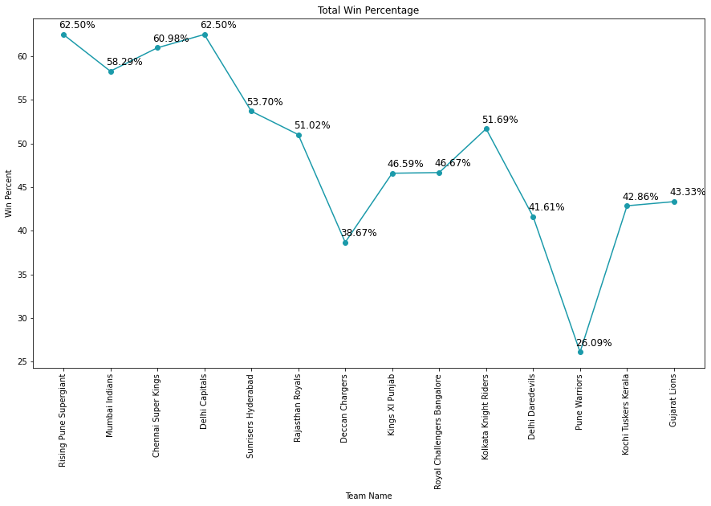

```python
fig,ax = plt.subplots(figsize=(15,8))
plt.plot(loc_df['team'],loc_df['Win_percentage'], marker = 'o', color = sea_blue)
for index,data in enumerate(loc_df['Win_percentage']):
    plt.text(x=index-0.1 , y =data+0.7 , s="{:.2f}%".format(data) , fontdict=dict(fontsize=12))
plt.xlabel('Team Name')
plt.ylabel('Win Percent')
plt.title('Total Win Percentage')
plt.xticks(rotation='vertical')
plt.show()
```

##### Insight:

Delhi Capitals and Rising Pune Supergiants have astounding win probablity of 62.5%.

## Toss Analysis

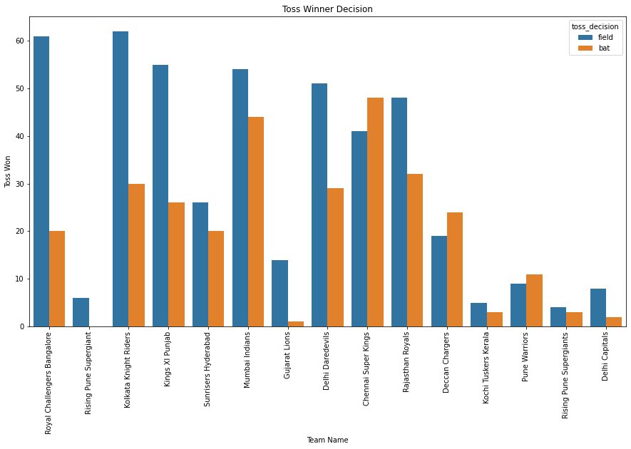

```python
# Top choice made by teams after winning a toss

fig,ax = plt.subplots(figsize=(15,8))
sns.countplot(x='toss_winner',data = mat_df,hue='toss_decision')
plt.xlabel('Team Name')
plt.ylabel('Toss Won')
plt.title('Toss Winner Decision')
plt.xticks(rotation='vertical')

plt.show()
```

###### Insight:

Apart from CSK, Deccan Chargers and Pune Warriors all teams prefered to opt for Fielding first.

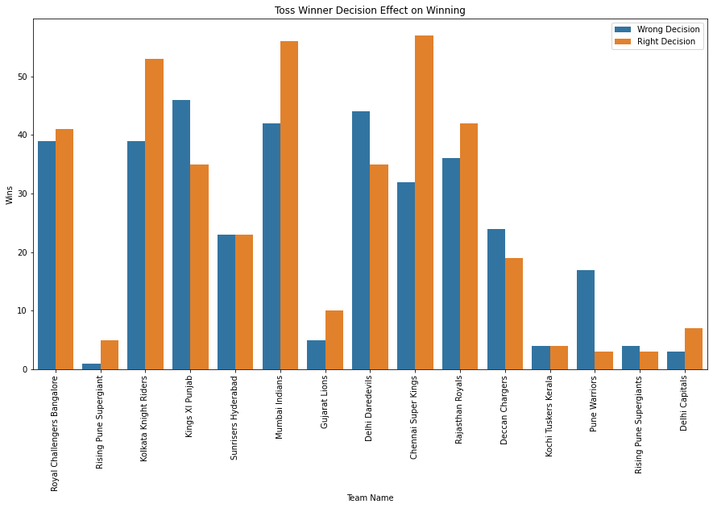

```python
# Analyzing if the decision made by team was right or not

## Creating Derived Columns

mat = mat_df.dropna(subset = ['winner'],axis =0)
mat['right_de'] = np.asarray(mat.toss_winner == mat.winner)

## Plotting

fig,ax = plt.subplots(figsize=(15,8))
sns.countplot(x='toss_winner',data = mat,hue='right_de')
plt.xlabel('Team Name')
plt.ylabel('Wins')
plt.title('Toss Winner Decision Effect on Winning')
plt.xticks(rotation='vertical')
plt.legend(labels = ['Wrong Decision','Right Decision'])

plt.show()
```

```python
# Teams winning as Chasers or target setters


mat['win_type'] = mat.toss_decision
for i in range(len(mat.toss_winner)):
    if mat.win_by_runs[i] > 0:
        mat.win_type[i] = 'bat'
    else:
        mat.win_type[i] = 'field'
```

[output not shown]

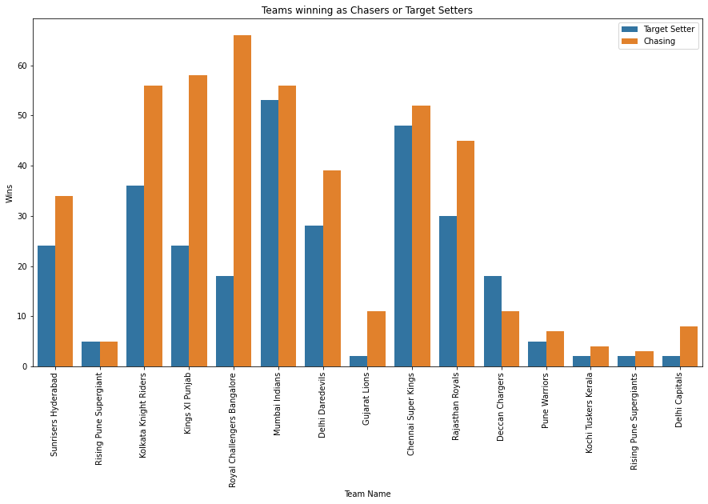

```python
fig,ax = plt.subplots(figsize=(15,8))
sns.countplot(x='winner',data = mat,hue='win_type')
plt.xlabel('Team Name')
plt.ylabel('Wins')
plt.title('Teams winning as Chasers or Target Setters')
plt.xticks(rotation='vertical')
plt.legend(labels = ['Target Setter','Chasing'])

plt.show()
```

##### Insight:

1. Most Teams have won matches when they field first with the exception of Deccan Chargers.
2. Most teams gameplay is of chasing type
3. CSK and MI has done well as both chasers as well as target setters

## Batsman Analysis

```python
players_df.Batting_Hand.unique()
```

```
array(['Right_Hand', 'Right_hand', 'Left_Hand', nan], dtype=object)
```

```python
players_df.Batting_Hand = players_df.Batting_Hand.apply(lambda x:'Right_Hand' if x == 'Right_hand' else x)
```

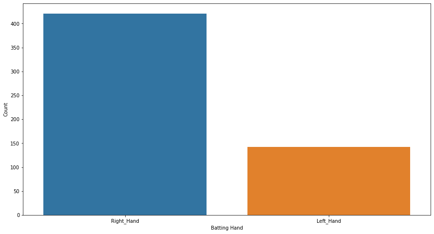

```python
# Batting Hand

fig,ax = plt.subplots(figsize=(15,8))
sns.countplot(x='Batting_Hand',data = players_df)
plt.xlabel('Batting Hand')
plt.ylabel('Count')
# plt.title('Battin')

plt.show()
```

##### Insight:

There are too many Right Handed players in the game when compared to Left Handed.

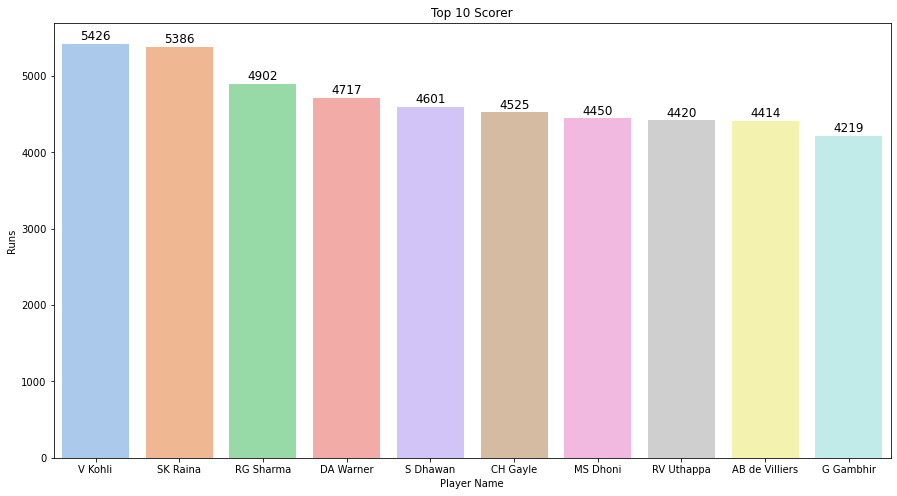

```python
# Top 10 Scorer in IPL

runs_df.sort_values(by=['total_runs'],ascending = False,inplace = True)
Player = runs_df.batsman.head(10)
Runs = runs_df.total_runs.head(10)
# plotting
fig,ax = plt.subplots(figsize=(15,8))
sns.barplot(Player,Runs,palette='pastel')
for index,data in enumerate(Runs):
    plt.text(x=index-0.18, y =data+50, s=f"{data}" , fontdict=dict(fontsize=12))
plt.xlabel('Player Name')
plt.ylabel('Runs')
plt.title('Top 10 Scorer')
# plt.show()
```

##### Insight:

Virat Kholi and SK Raina has undisputed lead in most runs scored, with Virat being in lead of 40 runs.

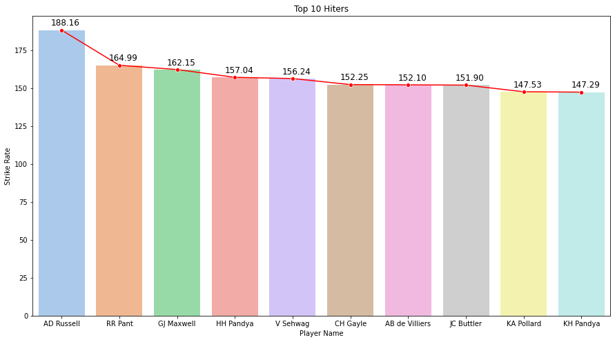

```python
# Top 10 Hiters of the series


# Some players had played only few balls so it would be unfair to plot the graph directly so we will make a /
# /threshold 0f 500 balls to plot the graph

runs_df.sort_values(by=['strikerate'],ascending = False,inplace = True)
Player = runs_df.batsman[runs_df.numberofballs>500].head(10)
SR = runs_df.strikerate[runs_df.numberofballs>500].head(10) # minimum 500 balls has been played by the player

# plotting

fig,ax = plt.subplots(figsize=(15,8))
sns.lineplot(Player,SR,marker = 'o',color = 'r')
sns.barplot(Player,SR, palette = 'pastel')

for index,data in enumerate(SR):
    plt.text(x=index-0.18, y =data+3, s="{:.2f}".format(data) , fontdict=dict(fontsize=12))
plt.xlabel('Player Name')
plt.ylabel('Strike Rate')
plt.title('Top 10 Hiters')
plt.show()
```

###### Insight:

AD Russell has a great record strike rate of 188.16.

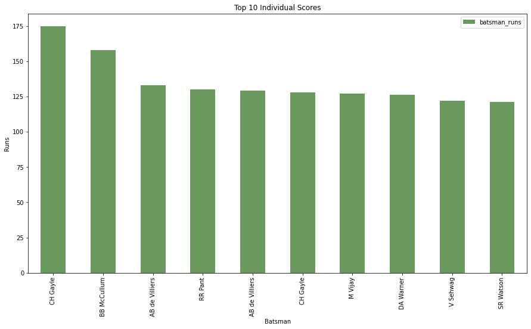

```python
# Top 10 highest Individual Score.


indi = deli_df.groupby(['match_id','batsman',])['batsman_runs'].sum().reset_index()
indi.sort_values('batsman_runs',axis=0, inplace=True,ascending=False)
indi = indi[:10]

indi.drop('match_id',inplace=True,axis=1)
indi.set_index('batsman',inplace=True)

#Plotting
indi.plot(kind= 'bar' , figsize = (15,8), color = green)
plt.xlabel('Batsman')
plt.ylabel('Runs')
plt.title('Top 10 Individual Scores')
plt.show()
```

##### Insight:

1. Chris Gayle and AB de Villiers has been in list twice (as expected from their striking rate graph)

```python
# Orange Cap Holders

name,runs = [],[]
for season in mat_df['Season'].unique():
    new_df = mat_df[mat_df['Season']==season]
    temp_df = deli_df[deli_df['match_id'].isin(new_df['id'].values)]
    temp_df = temp_df.groupby('batsman')['batsman_runs'].sum().reset_index()
    temp_df.sort_values('batsman_runs', inplace=True,ascending=False)
    temp_df = temp_df.iloc[0,:]
    name.append(temp_df['batsman'])
    runs.append(temp_df['batsman_runs'])

orange_df = pd.DataFrame(data={'Season':mat_df['Season'].unique(), 'Player':name, 'Total Runs':runs}, index = None)
print(orange_df.sort_values('Season'))
```

```
    Season         Player  Total Runs
1     2008       SE Marsh         616
2     2009      ML Hayden         572
3     2010   SR Tendulkar         618
4     2011       CH Gayle         608
5     2012       CH Gayle         733
6     2013     MEK Hussey         733
7     2014     RV Uthappa         660
8     2015      DA Warner         562
9     2016        V Kohli         973
0     2017      DA Warner         641
10    2018  KS Williamson         747
11    2019      DA Warner         727
```

###### Insight:

1. DA Warner has been Orange Cap Holder 3 times.
2. Virat Kholi had the maximum runs ever scored by the orange cap holder in a season

## Bowlers Analysis

```python
players_df.head()
```

|  | Player_Name | DOB | Batting_Hand | Bowling_Skill | Country |
| --- | --- | --- | --- | --- | --- |
| 0 | A Ashish Reddy | 1991-02-24 | Right_Hand | Right-arm medium | India |
| 1 | A Chandila | 1983-12-05 | Right_Hand | Right-arm offbreak | India |
| 2 | A Chopra | 1977-09-19 | Right_Hand | Right-arm offbreak | India |
| 3 | A Choudhary | NaT | Right_Hand | Left-arm fast-medium | NaN |
| 4 | A Dananjaya | NaT | Right_Hand | Right-arm offbreak | NaN |

```python
players_df.Bowling_Skill.nunique()
```

```
16
```

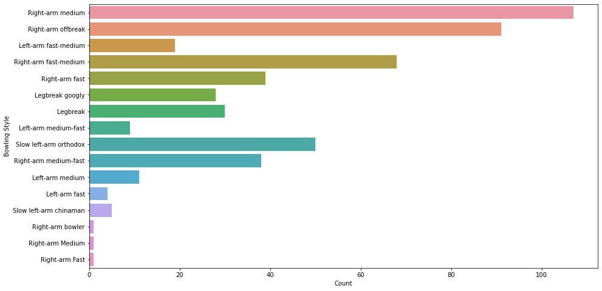

```python
# Bowling Skill

fig,ax = plt.subplots(figsize=(15,8))
sns.countplot(y='Bowling_Skill',data = players_df)
plt.ylabel('Bowling Style')
plt.xlabel('Count')
# plt.title('Battin')

plt.show()
```

```python
# Purple Cap Holders

name,wickets = [],[]

out = ['caught', 'bowled', 'lbw', 'caught and bowled',  'stumped', 'hit wicket']
for season in mat_df['Season'].unique():
    season_df = mat_df[mat_df['Season']==season]

    temp_df = deli_df[deli_df['match_id'].isin(season_df['id'].values)]
    temp_df = temp_df[temp_df['dismissal_kind'].isin(out)]
    temp_df = temp_df.groupby('bowler')['dismissal_kind'].count().reset_index()

    temp_df.sort_values('dismissal_kind', inplace=True,ascending=False)
    temp_df = temp_df.iloc[0,:]

    name.append(temp_df['bowler'])
    wickets.append(temp_df['dismissal_kind'])

purple_df = pd.DataFrame(data={'Season':mat_df['Season'].unique(), 'Bowler':name, 'Wickets':wickets})
purple_df.sort_values('Season')
```

|  | Season | Bowler | Wickets |
| --- | --- | --- | --- |
| 1 | 2008 | Sohail Tanvir | 22 |
| 2 | 2009 | RP Singh | 23 |
| 3 | 2010 | PP Ojha | 21 |
| 4 | 2011 | SL Malinga | 28 |
| 5 | 2012 | M Morkel | 25 |
| 6 | 2013 | DJ Bravo | 32 |
| 7 | 2014 | MM Sharma | 23 |
| 8 | 2015 | DJ Bravo | 26 |
| 9 | 2016 | B Kumar | 23 |
| 0 | 2017 | B Kumar | 26 |
| 10 | 2018 | AJ Tye | 24 |
| 11 | 2019 | Imran Tahir | 26 |

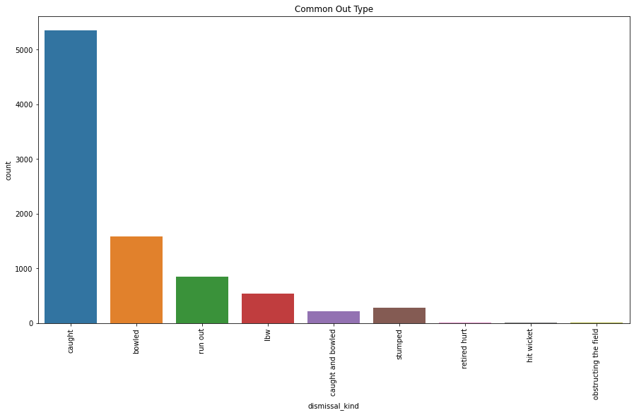

```python
# Most Common Out Type:
plt.figure(figsize=(15,8))
sns.countplot(data=deli_df, x='dismissal_kind')
plt.xticks(rotation=90)
plt.title('Common Out Type')
plt.show()
```

###### Insight:

1. The most common type of out is Catch Out
2. There were cases where player was assigned Out due to Obstructing the Field, injury or Hit wicket but as expected these are rare cases

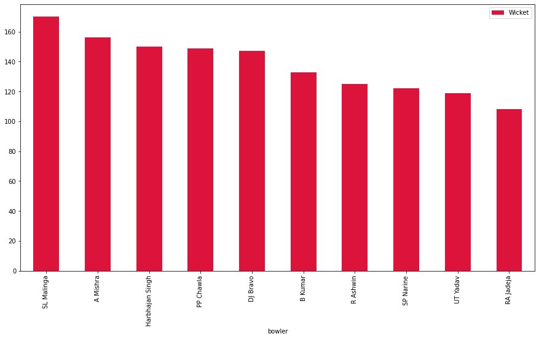

```python
# Top 10 Wicket Takers in Overall Series
out = ['caught', 'bowled', 'lbw', 'caught and bowled',  'stumped', 'hit wicket']
wickets_taker = deli_df[deli_df['dismissal_kind'].isin(out)]
wickets_taker = wickets_taker.groupby('bowler')['dismissal_kind'].count().reset_index()
wickets_taker.sort_values('dismissal_kind', ascending=False, inplace=True)
wickets_taker.set_index('bowler', inplace=True)
wickets_taker.head(10)
wickets_taker[:10].plot(kind= 'bar' , figsize = (15,8), color = crimson)
plt.legend(labels = ['Wicket'])
plt.show()
```

###### Insight:

1. Malinga has undisputed lead in taking most wickets

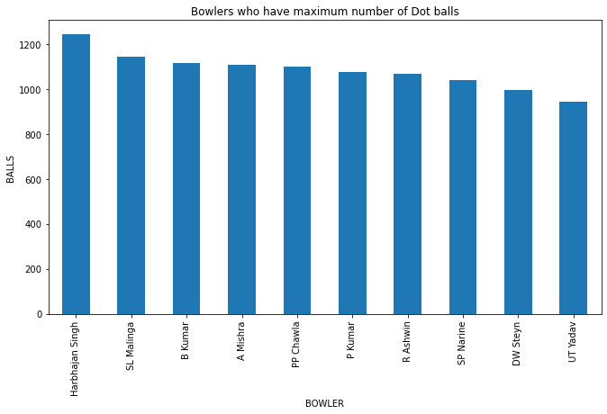

```python
# Top 10 bowlers with most dot balls

dot_ball = deli_df[deli_df['total_runs']==0]
dot_ball = dot_ball['bowler'].value_counts()[:10]
dot_ball.plot(kind='bar', figsize=(11,6), title='Bowlers who have maximum number of Dot balls')

plt.xlabel('BOWLER')
plt.ylabel('BALLS')
plt.show()
```

##### Insight:

1. Harbhajan has a recorded lead in throwing most dot balls.
2. SL Malinga stood 2nd in the table and 1st in most wicket ever taken making him the most fearsome bowler.